# ME414 - Estatística para Experimentalistas

## Inferência para duas populações: Intervalo de confiança para duas médias

## Intervalo de Confiança para Duas Médias

**População 1:** Coletamos uma amostra aleatória \(X_1, X_2, \ldots,X_n\) de uma população com média \(\mu_1\) e a variância \(\sigma_1^2\) e usamos \(\bar{X}\) para estimar \(\mu_1\).

**População 2:** Coletamos uma amostra aleatória \(Y_1, Y_2, \ldots,Y_m\) de uma população com média \(\mu_2\) e a variância \(\sigma_2^2\) e usamos \(\bar{Y}\) para estimar \(\mu_2\).

A população 1 é independente da população 2.

**Condições:**

1. As populações 1 e 2 são aproximadamente normais ou
2. Os tamanhos amostrais \(n\) e \(m\) são suficientemente grandes.

Se pelo menos uma das condições acima é satisfeita, temos: \[\bar{X} \sim N\left(\mu_1,\frac{\sigma_1^2}{n} \right) \quad \mbox{e} \quad \bar{Y} \sim N\left(\mu_2,\frac{\sigma_2^2}{m} \right)\]

## Intervalo de Confiança para Duas Médias

**Caso 1: Variâncias diferentes e conhecidas**

Assumindo que as duas amostras \(X_1, \ldots, X_n\) e \(Y_1, \ldots, Y_m\) são independentes com \(\sigma_1^2 \neq \sigma_2^2\) conhecidas, temos: \[ \bar{X} - \bar{Y} \sim N\left(\mu_1 - \mu_2, \frac{\sigma_1^{2}}{n} + \frac{\sigma_2^{2}}{m} \right)\]

E daí, \[Z= \frac{(\bar{X} - \bar{Y}) - (\mu_1 - \mu_2)}{\displaystyle \sqrt{\frac{\sigma_1^{2}}{n} + \frac{\sigma_2^{2}}{m}}} \sim N(0, 1)\]

## Intervalo de Confiança para Duas Médias

Do resultando anterior, similar com o que fizemos para uma média, podemos construir um IC de \(100(1-\alpha)\%\) para \(\mu_1 - \mu_2\) da seguinte forma:

\[P(-z_{\alpha/2} \leq Z \leq z_{\alpha/2}) = P \left( -z_{\alpha/2} \leq \frac{(\bar{X} - \bar{Y}) - (\mu_1 - \mu_2)}{\displaystyle \sqrt{\frac{\sigma_1^{2}}{n} + \frac{\sigma_2^{2}}{m}}} \leq z_{\alpha/2}\right) = 1-\alpha\]

Portanto, um IC de \(100(1-\alpha)\%\) para \(\mu_1 - \mu_2\) é dado por: \[IC(\mu_1 - \mu_2, 1-\alpha) = (\bar{x} - \bar{y}) \pm z_{\alpha/2} \sqrt{\frac{\sigma_1^{2}}{n} + \frac{\sigma_2^{2}}{m}}\]

## Relembrando: Como encontrar \(z_{\alpha/2}\)

\[P(|Z|\leq z_{\alpha/2})=P(-z_{\alpha/2}\leq Z \leq z_{\alpha/2})=1-\alpha\]

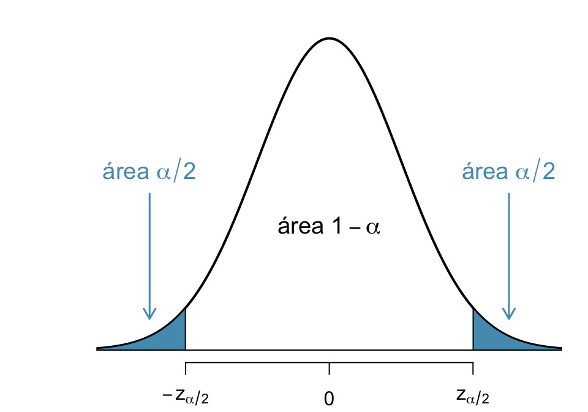

Procure na tabela o valor de \(z\) tal que a probabilidade acumulada até o valor de \(z\), isto é \(P(Z\leq z)=\Phi(z)\), seja \(1-\alpha/2\).

## Intervalo de Confiança para Duas Médias

**Caso 2: Variâncias iguais e conhecidas**

Considere o caso particular em que as variâncias são conhecidas e idênticas, isto é, \(\sigma_1^2 = \sigma_2^2 = \sigma^2\). Então, \[Z= \frac{(\bar{X} - \bar{Y}) - (\mu_1 - \mu_2)}{\displaystyle \sqrt{\sigma^2 \left(\frac{1}{n} + \frac{1}{m}\right) }} \sim N(0, 1)\]

E um IC de \(100(1-\alpha)\%\) para \(\mu_1 - \mu_2\) é dado por: \[IC(\mu_1 - \mu_2, 1-\alpha) = (\bar{x} - \bar{y}) \pm z_{\alpha/2} \sqrt{\sigma^2 \left(\frac{1}{n} + \frac{1}{m} \right)}\]

## Intervalo de Confiança para Duas Médias

**Caso 3: Variâncias iguais e desconhecidas**

E se as variâncias das duas populações são idênticas porém desconhecidas, isto é, \(\sigma_1^2 = \sigma_2^2 = \sigma^2\), \(\sigma^2\) desconhecida?

Assim como no caso de uma média com variância desconhecida, usamos uma estimativa de \(\sigma^2\) e a distribuição normal é substituída pela distribuição \(t\).

No caso de duas populações, o estimador da variância \(\sigma^2\) é a combinação das variâncias amostrais de cada população, ou seja, \[S_p^2 = \frac{(n-1)S_1^2 + (m-1)S_2^2}{n+m-2},\] sendo \(S_i^2\) é a variância amostral da população \(i\).

## Intervalo de Confiança para Duas Médias

Então temos:\(\displaystyle \quad T= \frac{(\bar{X} - \bar{Y}) - (\mu_1 - \mu_2)}{\displaystyle \sqrt{S_p^2 \left(\frac{1}{n} + \frac{1}{m}\right) }} \sim t_{n+m-2}\)

E um IC de \(100(1-\alpha)\%\) para \(\mu_1 - \mu_2\) é dado por: \[IC(\mu_1 - \mu_2, 1-\alpha) = (\bar x - \bar y) \pm t_{n+m-2, \alpha/2} \sqrt{S_p^2 \left(\frac{1}{n} + \frac{1}{m} \right)}\]

**Observação:** Se \(n\) e \(m\) são pequenos, as duas amostras devem vir de populações aproximadamente normais. Se \(n\) e \(m\) são grandes, então a distribuição \(t\) com \(n+m-2\) graus de liberdade aproxima-se de uma normal.

## Relembrando: Como encontrar \(t_{\nu,\alpha/2}\)

\[P(-t_{\nu,\alpha/2} < T < t_{\nu,\alpha/2}) = 1-\alpha\]

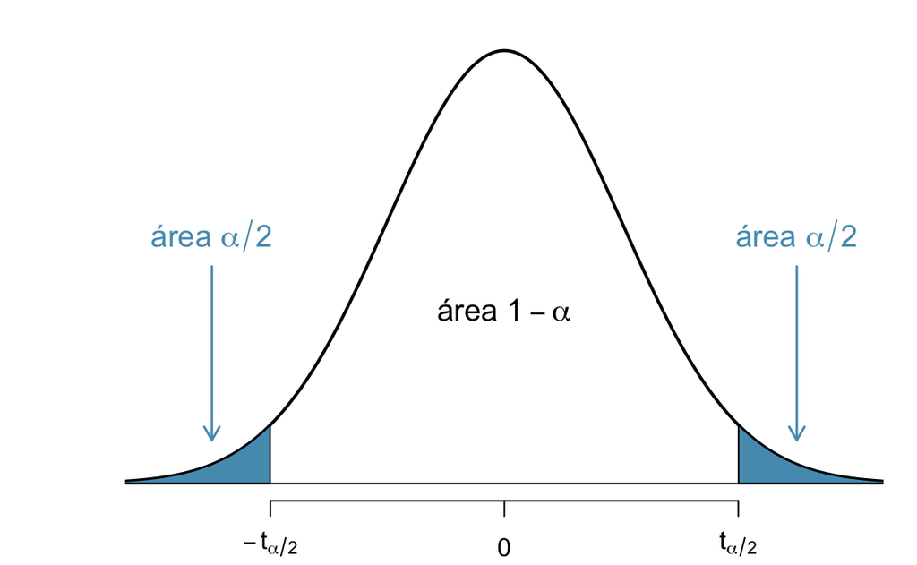

Nesse caso, \(\nu=n+m-2\) e os valores da distribuição \(t\) encontram-se tabelados.

## Intervalo de Confiança para Duas Médias

Resumindo:

| Variâncias | Margem de Erro | \(IC(\mu_1 - \mu_2, 1-\alpha)\) |
| --- | --- | --- |
| Diferentes e conhecidas (\(\sigma_1^2 \neq \sigma_2^2\)) | \(z_{\alpha/2} \sqrt{\displaystyle \frac{\sigma_1^{2}}{n} + \frac{\sigma_2^{2}}{m}}\) | \((\bar{x} - \bar{y}) \pm z_{\alpha/2} \sqrt{\displaystyle \frac{\sigma_1^{2}}{n} + \frac{\sigma_2^{2}}{m}}\) |
| Iguais e conhecidas (\(\sigma_1^2 = \sigma_2^2 =\sigma^2\)) | \(z_{\alpha/2} \sqrt{\displaystyle \sigma^2 \left(\frac{1}{n} + \frac{1}{m} \right)}\) | \((\bar{x} - \bar{y}) \pm z_{\alpha/2} \sqrt{\displaystyle \sigma^2 \left(\frac{1}{n} + \frac{1}{m} \right)}\) |
| Iguais e desconhecidas \((\sigma_1^2 = \sigma_2^2 =\sigma^2)\) | \(t_{n+m-2, \alpha/2} \sqrt{\displaystyle S_p^2 \left(\frac{1}{n} + \frac{1}{m} \right)}\) | \((\bar{x} - \bar{y}) \pm t_{n+m-2, \alpha/2} \sqrt{\displaystyle S_p^2 \left(\frac{1}{n} + \frac{1}{m} \right)}\) |

## Exemplo: Tempos de Incubação

Suspeita-se que o tempo de incubação do vírus 1 é maior que o do vírus 2.

Realizaram um estudo de controle e os tempos de incubação (em meses) desses dois vírus foram registrados.

Sabe-se que:

- O tempo de incubação do vírus 1 segue uma distribuição normal com média \(\mu_1\) e desvio padrão \(\sigma_{1}=\sqrt{2}\).
- O tempo de incubação do vírus 2 segue uma distribuição normal com média \(\mu_2\) e desvio padrão \(\sigma_{2}=1\).
- Os tempos de incubação de ambos os vírus são considerados independentes.

Construa um IC de \(95\%\) para a diferença do tempo médio de incubação entre os vírus, isto é, \(\mu_1 - \mu_2\).

## Exemplo: Tempos de Incubação

Os tempos de incubação (em meses) registrados foram:

X: tempo de incubação do vírus 1 (20 observações)

| 4.56 | 3.72 | 3.45 | 2.86 | 4.03 | 4.08 | 6.56 | 4.31 | 0.42 | 5.56 |
| --- | --- | --- | --- | --- | --- | --- | --- | --- | --- |
| 5.92 | 2.65 | 4.54 | 4.04 | 4.23 | 6.24 | 6.16 | 5.46 | 3.22 | 2.28 |

Y: tempo de incubação do vírus 2 (22 observações)

| 2.44 | 1.49 | 2.68 | 2.60 | 1.51 | 1.60 | 1.47 | 3.70 | 2.22 | 1.78 | 2.36 |
| --- | --- | --- | --- | --- | --- | --- | --- | --- | --- | --- |
| 1.56 | 2.98 | 3.33 | 2.22 | 0.58 | 2.26 | 2.26 | 1.92 | 0.50 | 1.17 | 1.70 |

Pelo enunciado, as duas populações são normais e as variâncias são diferentes, mas conhecidas: \(\sigma_1^2 = 2\) e \(\sigma_2^2= 1\). Além disso, \(n=20\) e \(m=22\).

## Exemplo: Tempos de Incubação

Calculamos as médias amostrais das duas populações: \(\bar x=4.21\) e \(\bar y = 2.02\).

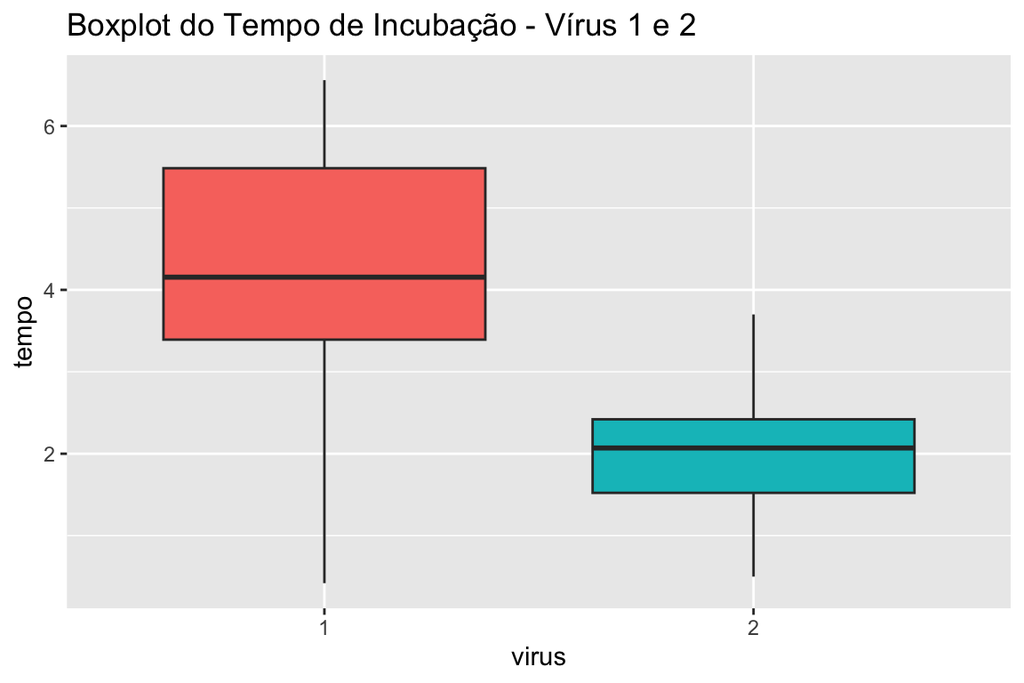

## Exemplo: Tempos de Incubação

Portanto, um Intervalo de \(95\%\) de confiança para \(\mu_1-\mu_2\) é dado por: \[\begin{aligned} IC(\mu_1-\mu_2, 0.95)&= (\bar x - \bar y) \pm z_{0.025} \sqrt{\frac{\sigma_1^{2}}{n} + \frac{\sigma_2^{2}}{m}} \\ &= (4.21 - 2.02) \pm 1.96 \sqrt{\frac{2}{20} + \frac{1}{22}} \\ &= 2.19 \pm 1.96 \times 0.38 \\ &= 2.19 \pm 0.75 \\ &= [1.44; 2.94] \end{aligned}\]

**Interpretação:** Com grau de confiança igual a 95%, estimamos que a diferença entre o tempo médio de incubação do vírus 1 para o vírus 2 está entre 1.44 e 2.94 meses.

## Exemplo: Tecidos

Dois tipos diferentes de tecido devem ser comparados. Uma máquina de testes *Martindale* pode comparar duas amostras ao mesmo tempo. Os pesos (em miligramas) para sete experimentos foram:

| Tecido | 1 | 2 | 3 | 4 | 5 | 6 | 7 |
| --- | --- | --- | --- | --- | --- | --- | --- |
| A | 36 | 26 | 31 | 38 | 28 | 20 | 37 |
| B | 39 | 27 | 35 | 42 | 31 | 39 | 22 |

Construa um IC de 95% para a diferença entre os pesos médios dos tecidos. Admita que a variância é a mesma, e igual a 49.

Quais outras suposições são necessárias para que o IC seja válido?  
**Fonte:** Adaptado das Notas de aula, Profa. Nancy Garcia.

## Exemplo: Tecidos

Os tecidos do tipo A tem uma média amostral igual a \(\bar{x}_A=30.86\).  
Já os tecidos do tipo B têm média amostral de \(\bar{x}_B=33.57\).

A **variância populacional** é igual a 49, enquanto as **variâncias amostrais** são 44.14 e 52.62, respectivamente.

**Suposições:**

- Como os tamanhos amostrais \(n=m=7\) são pequenos, devemos assumir os pesos dos tecidos dos dois tipos são normalmente distribuídos ou seja, \(X_A \sim N(\mu_A, \sigma^2)\) e \(X_B \sim N(\mu_B, \sigma^2)\).
- Além disso, são independentes e com variâncias iguais.

## Exemplo: Tecidos

Assumindo que as variâncias são iguais e **conhecidas** (\(\sigma_1^2=\sigma_2^2=49\)), um IC de 95% para \(\mu_A - \mu_B\) é dado por: \[\begin{aligned} IC(\mu_A - \mu_B, 0.95) &= (\bar x_A - \bar x_B) \pm z_{0.025} \sqrt{\sigma^2 \left(\frac{1}{n} + \frac{1}{m} \right)} \\ &= (30.86 - 33.57) \pm 1.96 \sqrt{49 \left(\frac{1}{7} + \frac{1}{7}\right)} \\ &= -2.71 \pm 1.96 \times 3.74 \\ &= -2.71 \pm 7.33 \\ &= [-10.04; 4.62] \end{aligned}\]

Portanto, com um grau de confiança de 95%, estimamos que a diferença entre os pesos médios dos tecidos do tipo A e tipo B está entre -10.04 e 4.62mg.

## Exemplo: Tecidos

Vamos assumir agora que a variância populacional não fosse conhecida.

Assumindo ainda que as variâncias são iguais mas **desconhecidas**, vamos então estimar a variância amostral combinada.

Sabendo que \(S_1^2=44.14\), \(S_2^2=52.62\) e \(n=m=7\) temos: \[\begin{aligned} S_p^2 &= \frac{(n-1)S_1^2 + (m-1)S_2^2}{n+m-2}\\ &= \frac{(7-1) 44.14 + (7-1)52.62}{7 + 7 - 2} \\ &= 48.38 \end{aligned}\]

## Exemplo: Tecidos

Nesse caso, um IC de 95% para \(\mu_A - \mu_B\) é dado por: \[\begin{aligned} IC(\mu_A - \mu_B, 0.95) &= (\bar x_A - \bar x_B) \pm t_{n+m-2, 0.025} \sqrt{S_p^2 \left(\frac{1}{n} + \frac{1}{m} \right)} \\ &= (30.86 - 33.57) \pm 2.18 \sqrt{48.38 \left(\frac{1}{7} + \frac{1}{7}\right)} \\ &= -2.71 \pm 2.18 \times 3.72 \\ &= -2.71 \pm 8.11 = [-10.82; 5.4] \end{aligned}\]

Portanto, com um grau de confiança de 95%, estimamos que a diferença entre os pesos médios dos tecidos do tipo A e tipo B está entre -10.82 e 5.4mg.

Note que a margem de erro desse IC é maior que o caso anterior.

## Exemplo: Tempo de Adaptação

Num estudo comparativo do tempo médio de adaptação (em anos), uma amostra aleatória, de 50 homens e 50 mulheres de um grande complexo industrial, produziu os seguintes resultados:

| Estatística | Homens | Mulheres |
| --- | --- | --- |
| Média | 3.2 | 3.7 |
| Desvio Padrão | 0.8 | 0.9 |

Construa um IC de 95% para a diferença entre o tempo médio de adaptação para homens e mulheres.

**Fonte:** Adaptado de Morettin & Bussab, Estatística Básica \(5^a\) edição, pág 365.

## Exemplo: Tempo de Adaptação

Veja que não sabemos a variância populacional, mas temos os desvios padrão amostrais e estes são bem próximos. Então iremos assumir que as variâncias são iguais porém desconhecidas.

Nesse caso, vamos então estimar a variância amostral combinada.

Sabendo que \(S_H=0.8\), \(S_M=0.9\) e \(n=m=50\) temos: \[\begin{aligned} S_p^2 &= \frac{(n-1)S_H^2 + (m-1)S_M^2}{n + m - 2}\\ &= \frac{(50-1) (0.8)^2 + (50-1)(0.9)^2}{50 + 50 - 2} \\ &= 0.73 \end{aligned}\]

## Exemplo: Tempo de Adaptação

Nesse caso, um IC de 95% para \(\mu_H - \mu_M\) é dado por: \[\begin{aligned} IC(\mu_H - \mu_M, 0.95) &= (\bar x_H - \bar x_M) \pm t_{n+m-2, 0.025} \sqrt{S_p^2 \left(\frac{1}{n} + \frac{1}{m} \right)} \\ &= (3.2 - 3.7) \pm 1.98 \sqrt{0.73 \left(\frac{1}{50} + \frac{1}{50}\right)} \\ &= -0.5 \pm 1.98 \times 0.17 \\ &= -0.5 \pm 0.34 \\ &= [-0.84; -0.16] \end{aligned}\]

Com um grau de confiança de 95%, estimamos que a diferença entre os tempos médios de adaptação entre homens e mulheres está entre -0.84 e -0.16 anos, ou seja, aproximadamente entre 2 e 10 meses a mais para as mulheres.

## Intervalo de Confiança para Duas Proporções

Considere \(X_1, \ldots,X_{n_1}\) e \(Y_1, \ldots,Y_{n_2}\) duas amostras independentes de ensaios de Bernoulli tal que \(X \sim b(p_1)\) e \(Y \sim b(p_2)\), com probabilidade \(p_1\) e \(p_2\) de apresentarem uma certa característica.

Queremos encontrar um IC de confiança para a diferença entre as proporções \(p_1\) e \(p_2\), ou seja, um IC para \(p_1 – p_2\).

Em aulas anteriores vimos que: \[\hat p_1 \sim N\left(p_1,\frac{p_1(1-p_1)}{n_1} \right) \quad \mbox{e} \quad \hat p_2 \sim N\left(p_2,\frac{p_2(1-p_2)}{n_2} \right)\]

Como as variâncias de \(\hat p_1\) e \(\hat p_2\) dependem de \(p_1\) e \(p_2\) e, portanto, não são conhecidas, iremos usar uma estimativa dessas variâncias.

## Intervalo de Confiança para Duas Proporções

Ou seja, \[\hat p_1 \sim N\left(p_1,\frac{\hat p_1(1 - \hat p_1)}{n_1} \right) \quad \mbox{e} \quad \hat p_2 \sim N\left(p_2,\frac{\hat p_2(1 - \hat p_2)}{n_2} \right)\]

**Condições:** Todas as quantidades \(n_1\hat p_1, \; n_1(1- \hat p_1), \; n_2\hat p_2 \; \mbox{ e } \; n_2(1- \hat p_2)\) devem ser pelo menos igual a 10 para que a aproximação pela normal seja válida.

Então, \[Z = \frac{(\hat p_1 - \hat p_2) - (p_1 - p_2)}{\displaystyle \sqrt{\frac{\hat p_1(1 - \hat p_1)}{n_1} + \frac{\hat p_2(1 - \hat p_2)}{n_2}}} \sim N(0, 1)\]

## Intervalo de Confiança para Duas Proporções

Similar com o que fizemos para uma proporção, podemos então construir um IC de \(100(1-\alpha)\%\) para \(p_1 - p_2\) da seguinte forma:

\[P(-z_{\alpha/2} \leq Z \leq z_{\alpha/2}) = P \left( -z_{\alpha/2} \leq \frac{(\hat p_1 - \hat p_2) - (p_1 - p_2)}{\sqrt{\frac{\hat p_1(1 - \hat p_1)}{n_1} + \frac{\hat p_2 (1 - \hat p_2)}{n_2}}} \leq z_{\alpha/2}\right) = 1-\alpha\]

Então, um IC de \(100(1-\alpha)\%\) para \(p_1 - p_2\) é dado por: \[IC(p_1 - p_2, 1-\alpha) = (\hat p_1 - \hat p_2) \pm z_{\alpha/2} \sqrt{\frac{\hat p_1 (1 - \hat p_1)}{n_1} + \frac{\hat p_2 (1 - \hat p_2)}{n_2}}\]

## Exemplo: Embalagens de Sabonetes

Para o lançamento da nova embalagem de um sabonete a divisão de criação estuda duas propostas:

- A: amarela com letras vermelhas
- B: preta com letras douradas

Eles acreditam que a proposta A chama mais a atenção que B.

Realizaram uma pesquisa em dois supermercados “semelhantes” e perguntaram para um total de 1000 clientes se eles haviam notado a embalagem e então pediram para descrevê-la. Os resultados estão na tabela seguir.

## Exemplo: Embalagens de Sabonetes

| Proposta | Notaram | Não Notaram | Total |
| --- | --- | --- | --- |
| A | 168 | 232 | 400 |
| B | 180 | 420 | 600 |
| Total | 348 | 652 | 1000 |

Seja \(p_A\) a proporção de pessoas que notaram a proposta A e \(p_B\) a proporção de pessoas que notaram a proposta B. Encontre um IC de 95% para \(p_A – p_B\).

Usando os dados da tabela: \[\hat p_A = \frac{168}{400}=0.42 \quad \mbox{e} \quad \hat p_B = \frac{180}{600}=0.3\]

## Exemplo: Embalagens de Sabonetes

Veja que as condições são satisfeitas.

Então um IC de 95% para \(p_A - p_B\) é dado por: \[\begin{aligned} IC(p_A - p_B, 0.95) &= (\hat p_A - \hat p_B) \pm z_{0.025} \sqrt{\frac{\hat p_A (1 - \hat p_A)}{n_A} + \frac{\hat p_B (1 - \hat p_B)}{n_B}} \\ &= (0.42 - 0.3) \pm 1.96 \sqrt{\frac{0.42 (0.58)}{400} + \frac{0.3 (0.7)}{600}} \\ &= 0.12 \pm 1.96 \times 0.031 \\ &= 0.12 \pm 0.061 \\ &= [0.059; 0.181] \end{aligned}\]

Portanto, com um grau de confiança de 95%, estimamos que a diferença entre as proporções \(p_A\) e \(p_B\) está entre 0.059 e 0.181.

## Exemplo: Ensaio Clínico

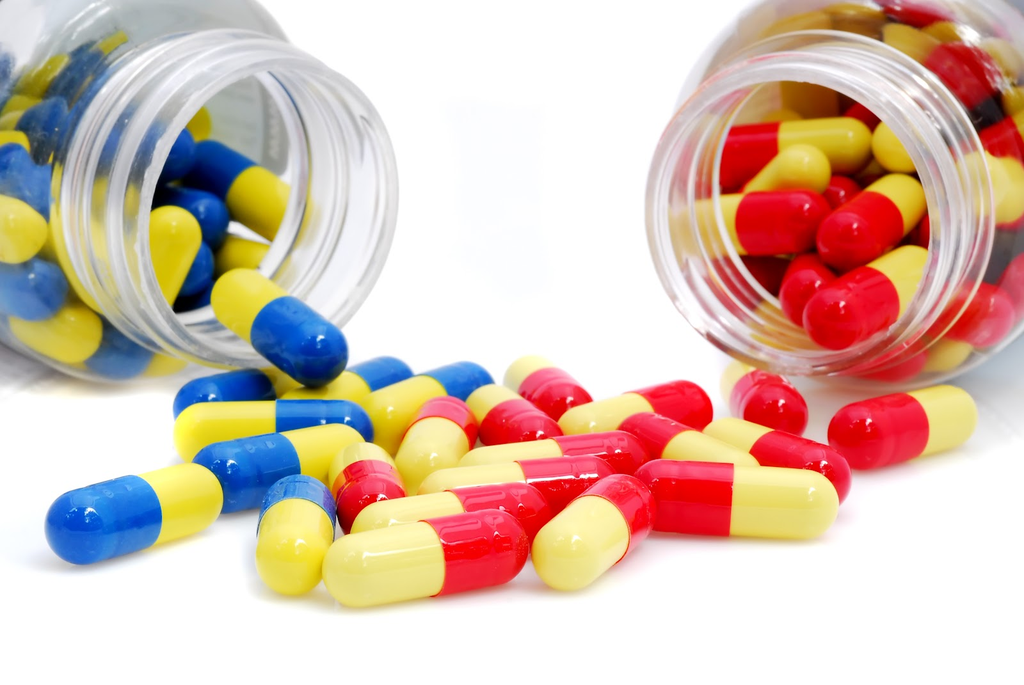

Um ensaio clínico é realizado para avaliar um novo tipo de tratamento contra uma doença e comparar os resultados com aqueles obtidos usando o tratamento tradicional.

- Dos 50 pacientes tratados com o tratamento novo, 36 se curaram.
- Dos 45 pacientes tratados com o tratamento antigo, 29 se curaram.

Seja \(p_1\) a proporção de curados com o tratamento novo e \(p_2\) a proporção de curados com o tratamento antigo.

Encontre um IC de 99% para \(p_1 - p_2\).

## Exemplo: Ensaio Clínico

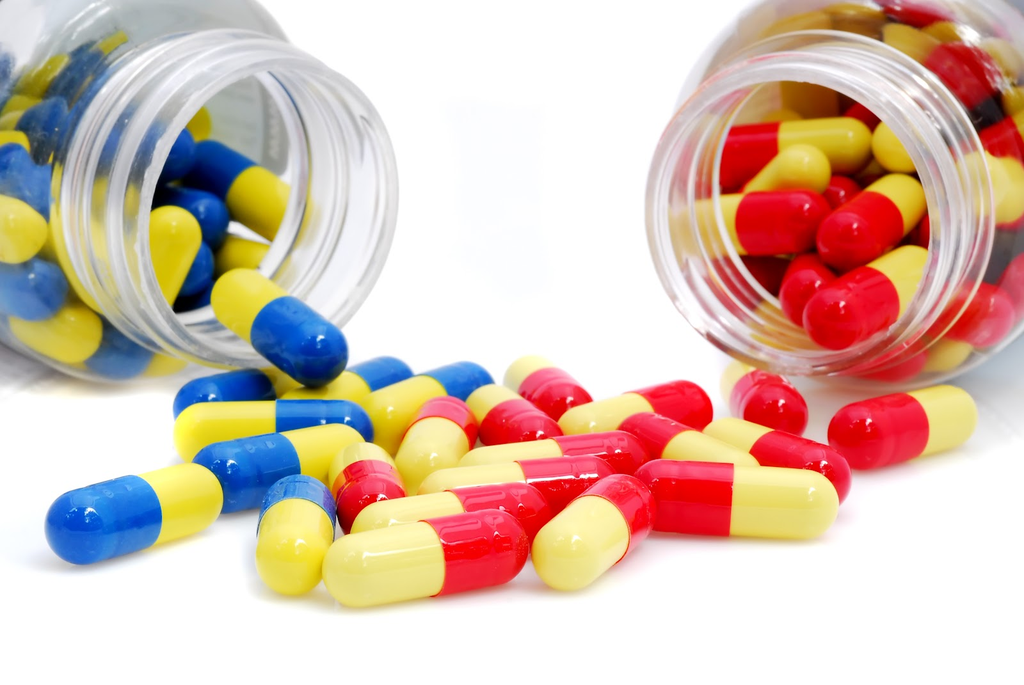

A proporção de curados pelos tratamentos novo e antigo são, respectivamente: \[\hat p_1 = \frac{36}{50}=0.72 \quad \mbox{e} \quad \hat p_2 = \frac{29}{45}=0.64\]

Então um IC de 99% para \(p_1 - p_2\) é dado por: \[\begin{aligned} IC(p_1 - p_2, 0.99) &= (0.72 - 0.64) \pm z_{0.005} \sqrt{\frac{0.72 (0.28)}{50} + \frac{0.64 (0.36)}{45}} \\ &= 0.08 \pm 2.58 \times 0.096 \\ &= 0.08 \pm 0.25 = [-0.17; 0.33] \end{aligned}\]

Portanto, com um grau de confiança de 99%, estimamos que a diferença entre as proporções de curados pelos tratamentos novo e antigo está entre -0.17 e 0.33.

## Leituras

- [Ross](http://www.sciencedirect.com/science/article/pii/B9780123743886000107): capítulo 10.
- [OpenIntro](https://www.openintro.org/stat/textbook.php): seção 5.3.1. e 6.2.2
- Magalhães: capítulo 9.

Slides produzidos pelos professores:

- Samara Kiihl
- Tatiana Benaglia
- Larissa Matos
- Benilton Carvalho